# Prediction of 30-Day Hospital Readmission in Patients with Diabetes

Sara Raees

2026-03-26

```r
required_packages <- c("tidyverse", "janitor", "caret", "naniar", "pROC", "randomForest", "skimr", "scales")

installed <- rownames(installed.packages())

for (pkg in required_packages) {
  if (!(pkg %in% installed)) {
    install.packages(pkg, dependencies = TRUE)
  }
}

library(tidyverse)
library(janitor)
library(skimr)
library(caret)
library(naniar)
library(pROC)
library(randomForest)
library(dplyr)
library(scales)
```

# Background

This project uses the Diabetes 130-US Hospitals for Years 1999–2008 dataset from the UCI Machine Learning Repository. The aim is to develop a prediction model for 30-day hospital readmission among hospitalized patients with diabetes.

For this assignment, a smaller stratified sample of the full dataset is used to reduce computational burden while preserving the proportion of patients readmitted within 30 days.

# Load, Read and Inspect the dataset

```r
diabetes_full <- read.csv("diabetic_data.csv", stringsAsFactors = FALSE)

# Create a smaller stratified sample for the assignment
set.seed(123)
sample_index <- createDataPartition(diabetes_full$readmitted, p = 20000 / nrow(diabetes_full), list = FALSE)
diabetes <- diabetes_full[sample_index, ]

names(diabetes)
```

```
##  [1] "encounter_id"             "patient_nbr"
##  [3] "race"                     "gender"
##  [5] "age"                      "weight"
##  [7] "admission_type_id"        "discharge_disposition_id"
##  [9] "admission_source_id"      "time_in_hospital"
## [11] "payer_code"               "medical_specialty"
## [13] "num_lab_procedures"       "num_procedures"
## [15] "num_medications"          "number_outpatient"
## [17] "number_emergency"         "number_inpatient"
## [19] "diag_1"                   "diag_2"
## [21] "diag_3"                   "number_diagnoses"
## [23] "max_glu_serum"            "A1Cresult"
## [25] "metformin"                "repaglinide"
## [27] "nateglinide"              "chlorpropamide"
## [29] "glimepiride"              "acetohexamide"
## [31] "glipizide"                "glyburide"
## [33] "tolbutamide"              "pioglitazone"
## [35] "rosiglitazone"            "acarbose"
## [37] "miglitol"                 "troglitazone"
## [39] "tolazamide"               "examide"
## [41] "citoglipton"              "insulin"
## [43] "glyburide.metformin"      "glipizide.metformin"
## [45] "glimepiride.pioglitazone" "metformin.rosiglitazone"
## [47] "metformin.pioglitazone"   "change"
## [49] "diabetesMed"              "readmitted"
```

```r
str(diabetes)
```

```
## 'data.frame':    20001 obs. of  50 variables:
##  $ encounter_id            : int  28236 36900 62256 183930 221634 252822 358776 377268 383430 419304 ...
##  $ patient_nbr             : int  89869032 77391171 49726791 107400762 21861756 18196434 101002446 104672268 80588529 99715041 ...
##  $ race                    : chr  "AfricanAmerican" "AfricanAmerican" "AfricanAmerican" "Caucasian" ...
##  $ gender                  : chr  "Female" "Male" "Female" "Female" ...
##  $ age                     : chr  "[40-50)" "[60-70)" "[60-70)" "[80-90)" ...
##  $ weight                  : chr  "?" "?" "?" "?" ...
##  $ admission_type_id       : int  1 2 3 2 1 1 1 2 1 2 ...
##  $ discharge_disposition_id: int  1 1 1 6 1 2 6 1 2 1 ...
##  $ admission_source_id     : int  7 4 2 1 7 7 7 2 7 2 ...
##  $ time_in_hospital        : int  9 7 1 11 1 5 7 1 1 7 ...
##  $ payer_code              : chr  "?" "?" "?" "?" ...
##  $ medical_specialty       : chr  "?" "?" "?" "?" ...
##  $ num_lab_procedures      : int  47 62 49 42 33 52 47 44 28 36 ...
##  $ num_procedures          : int  2 0 5 2 0 0 2 1 0 2 ...
```

[output cut: 36 more lines]

```r
dim(diabetes)
```

```
## [1] 20001    50
```

```r
table(diabetes$readmitted)
```

```
##
##   <30   >30    NO
##  2232  6986 10783
```

```r
diabetes[diabetes == "?"] <- NA

diabetes$readmit30 <- ifelse(diabetes$readmitted == "<30", 1, 0)
diabetes$readmit30 <- factor(diabetes$readmit30, levels = c(0,1), labels = c("No", "Yes"))

table(diabetes$readmit30)
```

```
##
##    No   Yes
## 17769  2232
```

```r
missing_summary <- sapply(diabetes, function(x) sum(is.na(x)))
missing_table <- data.frame(
  Variable = names(missing_summary),
  Missing_Count = as.numeric(missing_summary),
  Missing_Percent = round(as.numeric(missing_summary) / nrow(diabetes) * 100, 2)
)
missing_table <- missing_table[order(-missing_table$Missing_Count), ]
head(missing_table, 15)
```

```
##                    Variable Missing_Count Missing_Percent
## 6                    weight         19367           96.83
## 12        medical_specialty          9793           48.96
## 11               payer_code          7895           39.47
## 3                      race           433            2.16
## 21                   diag_3           286            1.43
## 20                   diag_2            71            0.35
## 19                   diag_1             2            0.01
## 1              encounter_id             0            0.00
## 2               patient_nbr             0            0.00
## 4                    gender             0            0.00
## 5                       age             0            0.00
## 7         admission_type_id             0            0.00
## 8  discharge_disposition_id             0            0.00
## 9       admission_source_id             0            0.00
## 10         time_in_hospital             0            0.00
```

```r
model_data <- diabetes %>%
  select(readmit30, race, gender, age, admission_type_id,
         discharge_disposition_id, admission_source_id,
         time_in_hospital, num_lab_procedures, num_procedures,
         num_medications, number_outpatient, number_emergency,
         number_inpatient, number_diagnoses, max_glu_serum,
         A1Cresult, insulin, change, diabetesMed)

str(model_data)
```

```
## 'data.frame':    20001 obs. of  20 variables:
##  $ readmit30               : Factor w/ 2 levels "No","Yes": 1 2 1 1 1 1 1 1 1 1 ...
##  $ race                    : chr  "AfricanAmerican" "AfricanAmerican" "AfricanAmerican" "Caucasian" ...
##  $ gender                  : chr  "Female" "Male" "Female" "Female" ...
##  $ age                     : chr  "[40-50)" "[60-70)" "[60-70)" "[80-90)" ...
##  $ admission_type_id       : int  1 2 3 2 1 1 1 2 1 2 ...
##  $ discharge_disposition_id: int  1 1 1 6 1 2 6 1 2 1 ...
##  $ admission_source_id     : int  7 4 2 1 7 7 7 2 7 2 ...
##  $ time_in_hospital        : int  9 7 1 11 1 5 7 1 1 7 ...
##  $ num_lab_procedures      : int  47 62 49 42 33 52 47 44 28 36 ...
##  $ num_procedures          : int  2 0 5 2 0 0 2 1 0 2 ...
##  $ num_medications         : int  17 11 2 19 7 14 22 15 15 9 ...
##  $ number_outpatient       : int  0 0 0 0 0 0 0 0 0 0 ...
##  $ number_emergency        : int  0 0 0 0 0 0 0 0 0 0 ...
##  $ number_inpatient        : int  0 0 0 0 0 0 0 0 0 0 ...
##  $ number_diagnoses        : int  9 7 8 8 3 8 8 9 4 5 ...
##  $ max_glu_serum           : chr  "None" "None" "None" "None" ...
##  $ A1Cresult               : chr  "None" "None" "None" "None" ...
##  $ insulin                 : chr  "Steady" "Steady" "Steady" "No" ...
##  $ change                  : chr  "No" "Ch" "No" "No" ...
##  $ diabetesMed             : chr  "Yes" "Yes" "Yes" "No" ...
```

```r
summary(model_data)
```

```
##  readmit30       race              gender              age
##  No :17769   Length:20001       Length:20001       Length:20001
##  Yes: 2232   Class :character   Class :character   Class :character
##              Mode  :character   Mode  :character   Mode  :character
##
##
##
##  admission_type_id discharge_disposition_id admission_source_id
##  Min.   :1.000     Min.   : 1.000           Min.   : 1.000
##  1st Qu.:1.000     1st Qu.: 1.000           1st Qu.: 1.000
##  Median :1.000     Median : 1.000           Median : 7.000
##  Mean   :2.004     Mean   : 3.644           Mean   : 5.721
##  3rd Qu.:3.000     3rd Qu.: 3.000           3rd Qu.: 7.000
##  Max.   :8.000     Max.   :28.000           Max.   :22.000
##  time_in_hospital num_lab_procedures num_procedures  num_medications
##  Min.   : 1.000   Min.   :  1.00     Min.   :0.000   Min.   : 1.00
##  1st Qu.: 2.000   1st Qu.: 31.00     1st Qu.:0.000   1st Qu.:10.00
##  Median : 4.000   Median : 44.00     Median :1.000   Median :15.00
##  Mean   : 4.361   Mean   : 43.14     Mean   :1.338   Mean   :15.97
##  3rd Qu.: 6.000   3rd Qu.: 57.00     3rd Qu.:2.000   3rd Qu.:20.00
##  Max.   :14.000   Max.   :120.00     Max.   :6.000   Max.   :72.00
##  number_outpatient number_emergency  number_inpatient  number_diagnoses
##  Min.   : 0.0000   Min.   : 0.0000   Min.   : 0.0000   Min.   : 1.000
##  1st Qu.: 0.0000   1st Qu.: 0.0000   1st Qu.: 0.0000   1st Qu.: 6.000
##  Median : 0.0000   Median : 0.0000   Median : 0.0000   Median : 8.000
##  Mean   : 0.3626   Mean   : 0.1951   Mean   : 0.6389   Mean   : 7.406
##  3rd Qu.: 0.0000   3rd Qu.: 0.0000   3rd Qu.: 1.0000   3rd Qu.: 9.000
##  Max.   :27.0000   Max.   :29.0000   Max.   :19.0000   Max.   :16.000
##  max_glu_serum       A1Cresult           insulin             change
##  Length:20001       Length:20001       Length:20001       Length:20001
##  Class :character   Class :character   Class :character   Class :character
##  Mode  :character   Mode  :character   Mode  :character   Mode  :character
##
##
##
##  diabetesMed
##  Length:20001
##  Class :character
##  Mode  :character
##
##
##
```

# Initial data overview

```r
glimpse(diabetes)
```

```
## Rows: 20,001
## Columns: 51
## $ encounter_id             <int> 28236, 36900, 62256, 183930, 221634, 252822, …
## $ patient_nbr              <int> 89869032, 77391171, 49726791, 107400762, 2186…
## $ race                     <chr> "AfricanAmerican", "AfricanAmerican", "Africa…
## $ gender                   <chr> "Female", "Male", "Female", "Female", "Female…
## $ age                      <chr> "[40-50)", "[60-70)", "[60-70)", "[80-90)", "…
## $ weight                   <chr> NA, NA, NA, NA, NA, NA, NA, NA, NA, NA, NA, N…
## $ admission_type_id        <int> 1, 2, 3, 2, 1, 1, 1, 2, 1, 2, 1, 3, 1, 1, 2, …
## $ discharge_disposition_id <int> 1, 1, 1, 6, 1, 2, 6, 1, 2, 1, 11, 1, 5, 1, 1,…
## $ admission_source_id      <int> 7, 4, 2, 1, 7, 7, 7, 2, 7, 2, 7, 2, 7, 7, 4, …
## $ time_in_hospital         <int> 9, 7, 1, 11, 1, 5, 7, 1, 1, 7, 7, 4, 1, 12, 4…
## $ payer_code               <chr> NA, NA, NA, NA, NA, NA, NA, NA, NA, NA, NA, N…
## $ medical_specialty        <chr> NA, NA, NA, NA, NA, "Cardiology", NA, NA, "Ca…
## $ num_lab_procedures       <int> 47, 62, 49, 42, 33, 52, 47, 44, 28, 36, 72, 5…
```

[output cut: 38 more lines]

```r
summary(diabetes)
```

```
##   encounter_id        patient_nbr            race              gender
##  Min.   :    28236   Min.   :      774   Length:20001       Length:20001
##  1st Qu.: 86031324   1st Qu.: 23448780   Class :character   Class :character
##  Median :152673534   Median : 45511560   Mode  :character   Mode  :character
##  Mean   :166388616   Mean   : 54392962
##  3rd Qu.:231841554   3rd Qu.: 87531372
##  Max.   :443847782   Max.   :189445127
##      age               weight          admission_type_id
##  Length:20001       Length:20001       Min.   :1.000
##  Class :character   Class :character   1st Qu.:1.000
##  Mode  :character   Mode  :character   Median :1.000
##                                        Mean   :2.004
##                                        3rd Qu.:3.000
##                                        Max.   :8.000
##  discharge_disposition_id admission_source_id time_in_hospital
##  Min.   : 1.000           Min.   : 1.000      Min.   : 1.000
##  1st Qu.: 1.000           1st Qu.: 1.000      1st Qu.: 2.000
##  Median : 1.000           Median : 7.000      Median : 4.000
##  Mean   : 3.644           Mean   : 5.721      Mean   : 4.361
##  3rd Qu.: 3.000           3rd Qu.: 7.000      3rd Qu.: 6.000
##  Max.   :28.000           Max.   :22.000      Max.   :14.000
##   payer_code        medical_specialty  num_lab_procedures num_procedures
##  Length:20001       Length:20001       Min.   :  1.00     Min.   :0.000
##  Class :character   Class :character   1st Qu.: 31.00     1st Qu.:0.000
##  Mode  :character   Mode  :character   Median : 44.00     Median :1.000
##                                        Mean   : 43.14     Mean   :1.338
##                                        3rd Qu.: 57.00     3rd Qu.:2.000
##                                        Max.   :120.00     Max.   :6.000
##  num_medications number_outpatient number_emergency  number_inpatient
##  Min.   : 1.00   Min.   : 0.0000   Min.   : 0.0000   Min.   : 0.0000
##  1st Qu.:10.00   1st Qu.: 0.0000   1st Qu.: 0.0000   1st Qu.: 0.0000
##  Median :15.00   Median : 0.0000   Median : 0.0000   Median : 0.0000
##  Mean   :15.97   Mean   : 0.3626   Mean   : 0.1951   Mean   : 0.6389
##  3rd Qu.:20.00   3rd Qu.: 0.0000   3rd Qu.: 0.0000   3rd Qu.: 1.0000
##  Max.   :72.00   Max.   :27.0000   Max.   :29.0000   Max.   :19.0000
##     diag_1             diag_2             diag_3          number_diagnoses
##  Length:20001       Length:20001       Length:20001       Min.   : 1.000
##  Class :character   Class :character   Class :character   1st Qu.: 6.000
##  Mode  :character   Mode  :character   Mode  :character   Median : 8.000
##                                                           Mean   : 7.406
```

[output cut: 43 more lines]

```
##
##  metformin.rosiglitazone metformin.pioglitazone    change
##  Length:20001            Length:20001           Length:20001
##  Class :character        Class :character       Class :character
##  Mode  :character        Mode  :character       Mode  :character
##
##
##
##  diabetesMed         readmitted        readmit30
##  Length:20001       Length:20001       No :17769
##  Class :character   Class :character   Yes: 2232
##  Mode  :character   Mode  :character
##
##
##
```

# Replace “?” with NA

```r
diabetes <- diabetes %>%
  mutate(across(where(is.character), ~ trimws(.))) %>%
  mutate(across(where(is.character), ~ na_if(., "?")))
```

# Define the outcome variable

The original variable `readmitted` has three categories:

- `"NO"` = no readmission
- `">30"` = readmission after 30 days
- `"<30"` = readmission within 30 days

We create a binary outcome:

- `1` = readmitted within 30 days
- `0` = not readmitted within 30 days

```r
diabetes <- diabetes %>%
  mutate(
    readmit30 = ifelse(readmitted == "<30", 1, 0),
    readmit30 = factor(readmit30, levels = c(0, 1), labels = c("No", "Yes"))
  )
```

# Study population and outcome frequency

```r
# Total number of observations
nrow(diabetes)
```

```
## [1] 20001
```

```r
# Total number of predictors before excluding IDs/outcome
ncol(diabetes) - 1
```

```
## [1] 50
```

```r
# Outcome distribution
table(diabetes$readmitted)
```

```
##
##   <30   >30    NO
##  2232  6986 10783
```

```r
table(diabetes$readmit30)
```

```
##
##    No   Yes
## 17769  2232
```

```r
# Proportion readmitted within 30 days
prop.table(table(diabetes$readmit30))
```

```
##
##        No       Yes
## 0.8884056 0.1115944
```

# Count number of patients readmitted within 30 days

```r
sum(diabetes$readmitted == "<30", na.rm = TRUE)
```

```
## [1] 2232
```

# Missing data assessment

```r
# Number of missing values per variable
missing_counts <- colSums(is.na(diabetes))

# Proportion missing per variable
missing_prop <- colMeans(is.na(diabetes)) * 100

missing_summary <- data.frame(
  Variable = names(diabetes),
  Missing_Count = missing_counts,
  Missing_Percent = round(missing_prop, 2)
) %>%
  arrange(desc(Missing_Percent))

missing_summary
```

```
##                                          Variable Missing_Count Missing_Percent
## weight                                     weight         19367           96.83
## medical_specialty               medical_specialty          9793           48.96
## payer_code                             payer_code          7895           39.47
## race                                         race           433            2.16
## diag_3                                     diag_3           286            1.43
## diag_2                                     diag_2            71            0.35
## diag_1                                     diag_1             2            0.01
## encounter_id                         encounter_id             0            0.00
## patient_nbr                           patient_nbr             0            0.00
## gender                                     gender             0            0.00
## age                                           age             0            0.00
## admission_type_id               admission_type_id             0            0.00
## discharge_disposition_id discharge_disposition_id             0            0.00
## admission_source_id           admission_source_id             0            0.00
## time_in_hospital                 time_in_hospital             0            0.00
## num_lab_procedures             num_lab_procedures             0            0.00
## num_procedures                     num_procedures             0            0.00
## num_medications                   num_medications             0            0.00
## number_outpatient               number_outpatient             0            0.00
## number_emergency                 number_emergency             0            0.00
## number_inpatient                 number_inpatient             0            0.00
## number_diagnoses                 number_diagnoses             0            0.00
## max_glu_serum                       max_glu_serum             0            0.00
## A1Cresult                               A1Cresult             0            0.00
## metformin                               metformin             0            0.00
## repaglinide                           repaglinide             0            0.00
## nateglinide                           nateglinide             0            0.00
## chlorpropamide                     chlorpropamide             0            0.00
## glimepiride                           glimepiride             0            0.00
## acetohexamide                       acetohexamide             0            0.00
## glipizide                               glipizide             0            0.00
## glyburide                               glyburide             0            0.00
## tolbutamide                           tolbutamide             0            0.00
## pioglitazone                         pioglitazone             0            0.00
## rosiglitazone                       rosiglitazone             0            0.00
## acarbose                                 acarbose             0            0.00
## miglitol                                 miglitol             0            0.00
## troglitazone                         troglitazone             0            0.00
## tolazamide                             tolazamide             0            0.00
## examide                                   examide             0            0.00
## citoglipton                           citoglipton             0            0.00
## insulin                                   insulin             0            0.00
## glyburide.metformin           glyburide.metformin             0            0.00
## glipizide.metformin           glipizide.metformin             0            0.00
## glimepiride.pioglitazone glimepiride.pioglitazone             0            0.00
## metformin.rosiglitazone   metformin.rosiglitazone             0            0.00
## metformin.pioglitazone     metformin.pioglitazone             0            0.00
## change                                     change             0            0.00
## diabetesMed                           diabetesMed             0            0.00
## readmitted                             readmitted             0            0.00
## readmit30                               readmit30             0            0.00
```

# Visualize missingness

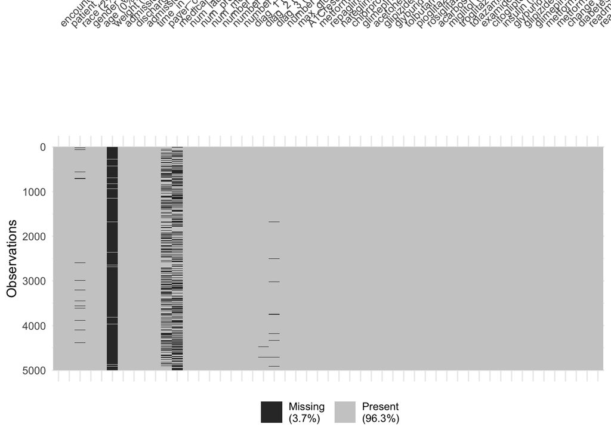

```r
diabetes %>%
  slice_sample(n = min(5000, nrow(diabetes))) %>%
  vis_miss()
```

# Descriptive analysis of selected variables

```r
# Age distribution
table(diabetes$age)
```

```
##
##   [0-10)  [10-20)  [20-30)  [30-40)  [40-50)  [50-60)  [60-70)  [70-80)
##       29      155      308      704     1889     3422     4402     5117
##  [80-90) [90-100)
##     3429      546
```

```r
# Gender distribution
table(diabetes$gender, useNA = "ifany")
```

```
##
## Female   Male
##  10649   9352
```

```r
# Race distribution
table(diabetes$race, useNA = "ifany")
```

```
##
## AfricanAmerican           Asian       Caucasian        Hispanic           Other
##            3700             126           15051             400             291
##            <NA>
##             433
```

```r
# Summary of selected numeric variables
diabetes %>%
  select(time_in_hospital, num_lab_procedures, num_procedures,
         num_medications, number_outpatient, number_emergency,
         number_inpatient, number_diagnoses) %>%
  summary()
```

```
##  time_in_hospital num_lab_procedures num_procedures  num_medications
##  Min.   : 1.000   Min.   :  1.00     Min.   :0.000   Min.   : 1.00
##  1st Qu.: 2.000   1st Qu.: 31.00     1st Qu.:0.000   1st Qu.:10.00
##  Median : 4.000   Median : 44.00     Median :1.000   Median :15.00
##  Mean   : 4.361   Mean   : 43.14     Mean   :1.338   Mean   :15.97
##  3rd Qu.: 6.000   3rd Qu.: 57.00     3rd Qu.:2.000   3rd Qu.:20.00
##  Max.   :14.000   Max.   :120.00     Max.   :6.000   Max.   :72.00
##  number_outpatient number_emergency  number_inpatient  number_diagnoses
##  Min.   : 0.0000   Min.   : 0.0000   Min.   : 0.0000   Min.   : 1.000
##  1st Qu.: 0.0000   1st Qu.: 0.0000   1st Qu.: 0.0000   1st Qu.: 6.000
##  Median : 0.0000   Median : 0.0000   Median : 0.0000   Median : 8.000
##  Mean   : 0.3626   Mean   : 0.1951   Mean   : 0.6389   Mean   : 7.406
##  3rd Qu.: 0.0000   3rd Qu.: 0.0000   3rd Qu.: 1.0000   3rd Qu.: 9.000
##  Max.   :27.0000   Max.   :29.0000   Max.   :19.0000   Max.   :16.000
```

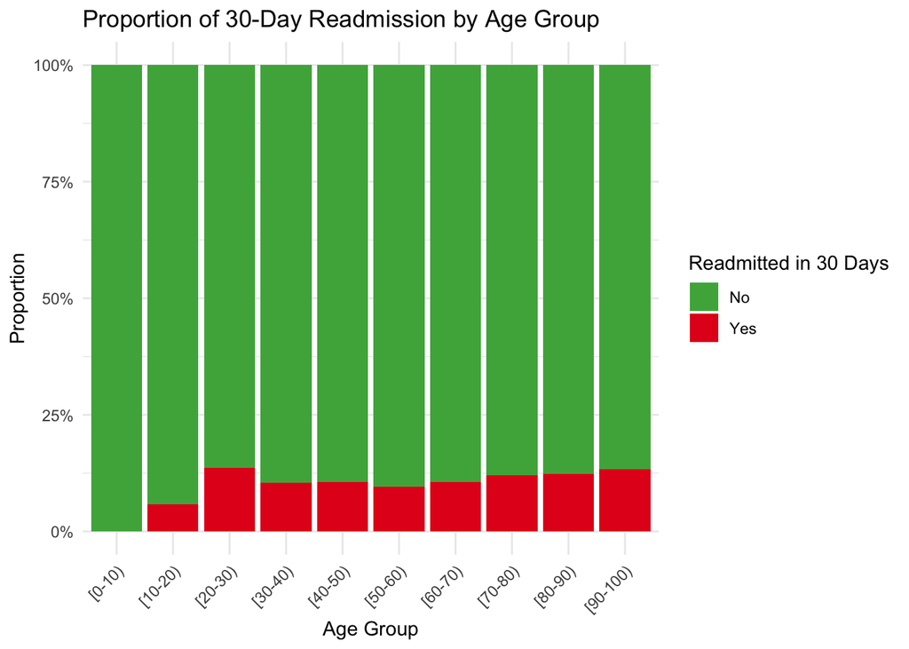

```r
# Coloured visualisations
ggplot(diabetes, aes(x = age, fill = readmit30)) +
  geom_bar(position = "fill") +
  scale_y_continuous(labels = percent_format()) +
  scale_fill_manual(values = c("No" = "#4DAF4A", "Yes" = "#E41A1C")) +
  labs(
    title = "Proportion of 30-Day Readmission by Age Group",
    x = "Age Group",
    y = "Proportion",
    fill = "Readmitted in 30 Days"
  ) +
  theme_minimal() +
  theme(axis.text.x = element_text(angle = 45, hjust = 1))
```

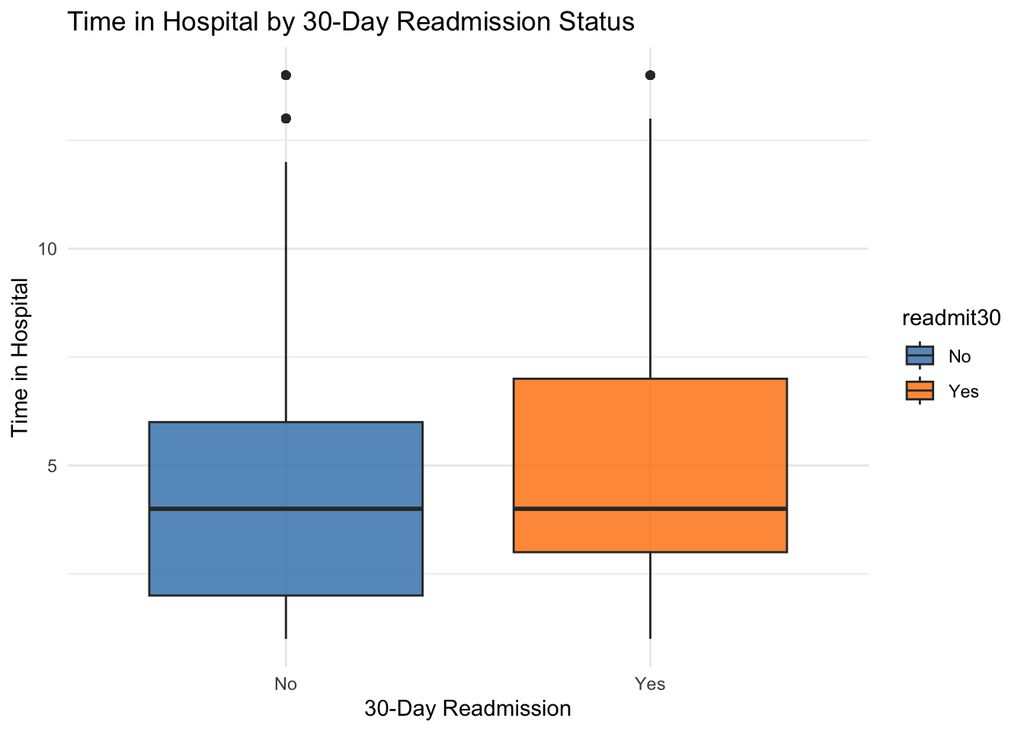

```r
ggplot(diabetes, aes(x = readmit30, y = time_in_hospital, fill = readmit30)) +
  geom_boxplot(alpha = 0.8) +
  scale_fill_manual(values = c("No" = "#377EB8", "Yes" = "#FF7F00")) +
  labs(
    title = "Time in Hospital by 30-Day Readmission Status",
    x = "30-Day Readmission",
    y = "Time in Hospital"
  ) +
  theme_minimal()
```

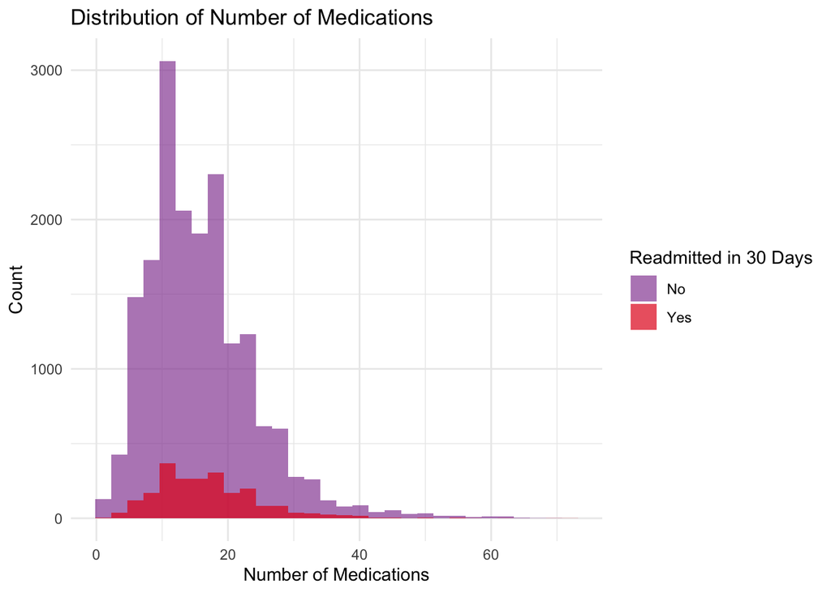

```r
ggplot(diabetes, aes(x = num_medications, fill = readmit30)) +
  geom_histogram(bins = 30, alpha = 0.7, position = "identity") +
  scale_fill_manual(values = c("No" = "#984EA3", "Yes" = "#E41A1C")) +
  labs(
    title = "Distribution of Number of Medications",
    x = "Number of Medications",
    y = "Count",
    fill = "Readmitted in 30 Days"
  ) +
  theme_minimal()
```

# Select variables for modelling

Remove identifier variables that should not be used as predictors.

```r
diabetes_model <- diabetes %>%
  select(-encounter_id, -patient_nbr, -readmitted)
```

# Convert character variables to factors

```r
diabetes_model <- diabetes_model %>%
  mutate(across(where(is.character), as.factor))
```

# Remove variables with very high missingness

```r
missing_threshold <- 0.5

diabetes_model <- diabetes_model %>%
  select(where(~ mean(is.na(.)) < missing_threshold))

dim(diabetes_model)
```

```
## [1] 20001    47
```

# Train/test split

```r
set.seed(123)

train_index <- createDataPartition(diabetes_model$readmit30, p = 0.7, list = FALSE)

train_data <- diabetes_model[train_index, ]
test_data  <- diabetes_model[-train_index, ]

dim(train_data)
```

```
## [1] 14002    47
```

```r
dim(test_data)
```

```
## [1] 5999   47
```

# Simple imputation

For a first analysis:

- numeric variables: median imputation
- categorical variables: create `"Missing"` level

```r
train_data_imputed <- train_data
test_data_imputed  <- test_data

# Numeric median imputation
num_vars <- names(train_data_imputed)[sapply(train_data_imputed, is.numeric)]

for (v in num_vars) {
  med <- median(train_data_imputed[[v]], na.rm = TRUE)
  if (is.na(med)) med <- 0
  train_data_imputed[[v]][is.na(train_data_imputed[[v]])] <- med
  test_data_imputed[[v]][is.na(test_data_imputed[[v]])] <- med
}

# Categorical missing category
cat_vars <- names(train_data_imputed)[sapply(train_data_imputed, is.factor)]

for (v in cat_vars) {
  train_data_imputed[[v]] <- addNA(train_data_imputed[[v]])
  levels(train_data_imputed[[v]])[is.na(levels(train_data_imputed[[v]]))] <- "Missing"

  test_data_imputed[[v]] <- factor(test_data_imputed[[v]], levels = levels(train_data_imputed[[v]]))
  test_data_imputed[[v]] <- addNA(test_data_imputed[[v]])
  levels(test_data_imputed[[v]])[is.na(levels(test_data_imputed[[v]]))] <- "Missing"
}
```

# Logistic regression model

```r
# Convert character to factor
train_data_imputed <- train_data_imputed %>%
  mutate(across(where(is.character), as.factor))

test_data_imputed <- test_data_imputed %>%
  mutate(across(where(is.character), as.factor))

# Match test levels to train
for (v in names(train_data_imputed)) {
  if (is.factor(train_data_imputed[[v]]) && v %in% names(test_data_imputed)) {
    test_data_imputed[[v]] <- factor(test_data_imputed[[v]],
                                     levels = levels(train_data_imputed[[v]]))
  }
}
```

```r
# Drop unused levels
train_data_imputed <- train_data_imputed %>%
  mutate(across(where(is.factor), droplevels))

test_data_imputed <- test_data_imputed %>%
  mutate(across(where(is.factor), droplevels))

# Remove factor columns with fewer than 2 observed categories
bad_vars <- names(train_data_imputed)[sapply(train_data_imputed, function(x) {
  if (is.factor(x)) {
    length(unique(na.omit(x))) < 2
  } else {
    FALSE
  }
})]

bad_vars
```

```
## [1] "acetohexamide"            "troglitazone"
## [3] "examide"                  "citoglipton"
## [5] "glipizide.metformin"      "glimepiride.pioglitazone"
## [7] "metformin.rosiglitazone"  "metformin.pioglitazone"
```

```r
train_data_imputed <- train_data_imputed %>% select(-all_of(bad_vars))
test_data_imputed  <- test_data_imputed %>% select(-all_of(bad_vars))

# Remove near-zero variance predictors
nzv <- nearZeroVar(train_data_imputed)
if (length(nzv) > 0) {
  train_data_imputed <- train_data_imputed[, -nzv, drop = FALSE]
  test_data_imputed  <- test_data_imputed[, colnames(train_data_imputed), drop = FALSE]
}
```

```r
# Fit logistic regression
logit_model <- glm(readmit30 ~ ., data = train_data_imputed, family = binomial)
summary(logit_model)
```

```
##
## Call:
## glm(formula = readmit30 ~ ., family = binomial, data = train_data_imputed)
##
## Coefficients: (23 not defined because of singularities)
##                                                         Estimate Std. Error
## (Intercept)                                            3.107e+15  1.061e+08
## raceAsian                                             -7.808e+13  7.794e+06
## raceCaucasian                                         -1.188e+12  1.700e+06
## raceHispanic                                          -6.449e+12  4.614e+06
## raceOther                                              5.033e+13  5.238e+06
## raceMissing                                           -1.201e+14  4.386e+06
## genderMale                                             2.391e+13  1.278e+06
## age[10-20)                                             5.058e+14  1.928e+07
## age[20-30)                                             4.415e+14  2.093e+07
## age[30-40)                                             3.437e+14  2.062e+07
## age[40-50)                                             2.138e+14  2.048e+07
## age[50-60)                                             2.512e+14  2.048e+07
## age[60-70)                                             2.066e+14  2.049e+07
## age[70-80)                                             2.066e+14  2.050e+07
## age[80-90)                                             2.612e+14  2.053e+07
## age[90-100)                                            3.045e+14  2.082e+07
## admission_type_id                                     -5.634e+12  4.804e+05
## discharge_disposition_id                              -1.974e+12  1.269e+05
## admission_source_id                                   -5.734e+12  1.679e+05
## time_in_hospital                                       2.021e+12  2.721e+05
## payer_codeCH                                          -2.197e+15  1.980e+07
## payer_codeCM                                           2.437e+13  5.332e+06
## payer_codeCP                                           1.545e+13  4.722e+06
## payer_codeDM                                           1.084e+14  8.301e+06
## payer_codeHM                                           4.681e+12  3.689e+06
## payer_codeMC                                           5.545e+13  3.094e+06
## payer_codeMD                                           3.621e+13  4.453e+06
## payer_codeMP                                          -8.262e+13  2.043e+07
## payer_codeOG                                          -5.196e+13  6.465e+06
## payer_codeOT                                          -3.067e+13  2.313e+07
## payer_codePO                                          -1.247e+15  8.937e+06
## payer_codeSI                                           1.517e+15  3.453e+07
## payer_codeSP                                           6.999e+13  3.895e+06
## payer_codeUN                                          -4.888e+13  4.870e+06
```

[output cut: 3278 more lines]

```
## insulinNo                                               -1633550   <2e-16 ***
## insulinSteady                                           27837027   <2e-16 ***
## insulinUp                                               34194225   <2e-16 ***
## changeNo                                                23536330   <2e-16 ***
## diabetesMedYes                                           -448007   <2e-16 ***
## ---
## Signif. codes:  0 '***' 0.001 '**' 0.01 '*' 0.05 '.' 0.1 ' ' 1
##
## (Dispersion parameter for binomial family taken to be 1)
##
##     Null deviance:   9798.7  on 14001  degrees of freedom
## Residual deviance: 131919.8  on 12367  degrees of freedom
## AIC: 135190
##
## Number of Fisher Scoring iterations: 25
```

# ROC and AUC

```r
test_data_imputed$readmit30 <- factor(test_data_imputed$readmit30, levels = c("No", "Yes"))

# Fix unseen factor levels in test data to match training data
factor_cols_logit <- names(train_data_imputed)[sapply(train_data_imputed, is.factor)]

for (col in factor_cols_logit) {
  if (col %in% names(test_data_imputed)) {
    test_data_imputed[[col]] <- as.character(test_data_imputed[[col]])
    test_data_imputed[[col]][!(test_data_imputed[[col]] %in% levels(train_data_imputed[[col]]))] <- NA
    test_data_imputed[[col]] <- factor(test_data_imputed[[col]], levels = levels(train_data_imputed[[col]]))
  }
}

# Keep only complete cases for prediction
test_logit_clean <- test_data_imputed[complete.cases(test_data_imputed), ]

# Logistic regression predicted probabilities
logit_pred_prob <- predict(logit_model, newdata = test_logit_clean, type = "response")

# ROC curve
library(pROC)

roc_logit <- roc(response = test_logit_clean$readmit30,
                 predictor = logit_pred_prob,
                 levels = c("No", "Yes"),
                 direction = "<")

# AUC
auc(roc_logit)
```

```
## Area under the curve: 0.5058
```

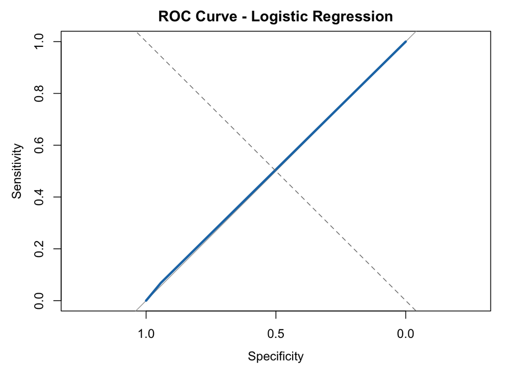

```r
# Plot ROC
plot(roc_logit, col = "#1F78B4", lwd = 3,
     main = "ROC Curve - Logistic Regression")
abline(a = 0, b = 1, lty = 2, col = "grey50")
```

# Create calibration data

```r
calibration_df <- data.frame(
  observed = ifelse(test_logit_clean$readmit30 == "Yes", 1, 0),
  predicted = logit_pred_prob
)

# Group predictions into deciles
calibration_plot_data <- calibration_df %>%
  mutate(decile = ntile(predicted, 10)) %>%
  group_by(decile) %>%
  summarise(
    mean_predicted = mean(predicted),
    mean_observed = mean(observed),
    .groups = "drop"
  )

calibration_plot_data
```

```
## # A tibble: 10 × 3
##    decile mean_predicted mean_observed
##     <int>          <dbl>         <dbl>
##  1      1       2.22e-16        0.111
##  2      2       2.22e-16        0.121
##  3      3       2.22e-16        0.0973
##  4      4       2.22e-16        0.131
##  5      5       2.22e-16        0.114
##  6      6       2.22e-16        0.116
##  7      7       2.22e-16        0.130
##  8      8       2.22e-16        0.0717
##  9      9       2.22e-16        0.115
## 10     10       5.81e- 1        0.116
```

# Calibration plot

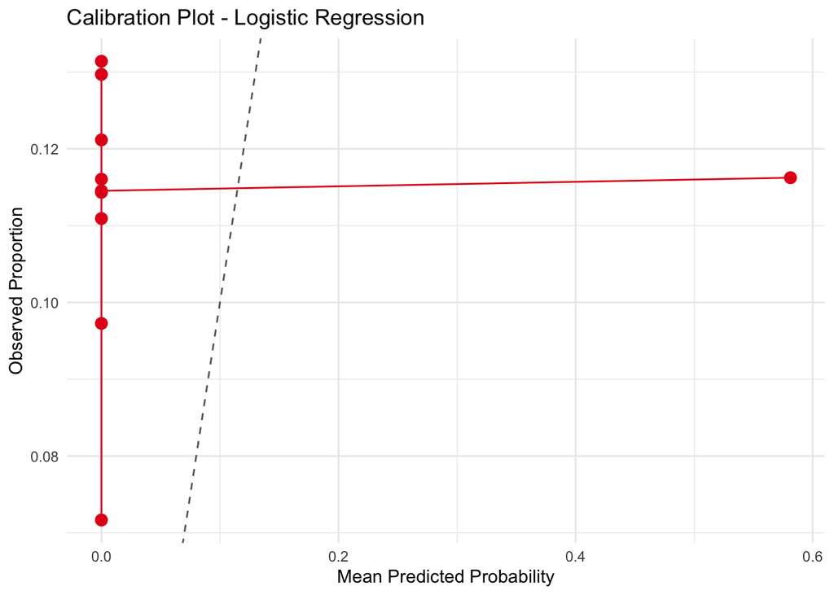

```r
ggplot(calibration_plot_data, aes(x = mean_predicted, y = mean_observed)) +
  geom_point(size = 3, colour = "#E41A1C") +
  geom_line(colour = "#E41A1C") +
  geom_abline(intercept = 0, slope = 1, linetype = "dashed", colour = "grey40") +
  labs(
    title = "Calibration Plot - Logistic Regression",
    x = "Mean Predicted Probability",
    y = "Observed Proportion"
  ) +
  theme_minimal()
```

# Brier score

```r
brier_logit <- mean((calibration_df$observed - calibration_df$predicted)^2)
brier_logit
```

```
## [1] 0.1550017
```

#Random Forest Model

```r
# Remove high-cardinality factor predictors from training data
high_card_vars <- names(train_data_imputed)[sapply(train_data_imputed, function(x) {
  is.factor(x) && nlevels(x) > 53
})]

high_card_vars
```

```
## [1] "medical_specialty" "diag_1"            "diag_2"
## [4] "diag_3"
```

```r
train_rf <- train_data_imputed %>%
  select(-all_of(high_card_vars))

test_rf <- test_data_imputed %>%
  select(all_of(names(train_rf)))

# Ensure outcome levels are consistent
train_rf$readmit30 <- factor(train_rf$readmit30, levels = c("No", "Yes"))
test_rf$readmit30  <- factor(test_rf$readmit30,  levels = c("No", "Yes"))
```

```r
set.seed(123)

rf_model <- randomForest(
  readmit30 ~ .,
  data = train_rf,
  ntree = 300,
  importance = TRUE
)

print(rf_model)
```

```
##
## Call:
##  randomForest(formula = readmit30 ~ ., data = train_rf, ntree = 300,      importance = TRUE)
##                Type of random forest: classification
##                      Number of trees: 300
## No. of variables tried at each split: 4
##
##         OOB estimate of  error rate: 11.18%
## Confusion matrix:
##        No Yes class.error
## No  12426  13   0.0010451
## Yes  1553  10   0.9936020
```

# Test set predictions

```r
# Test set predictions

# Ensure outcome is a factor with consistent levels
train_rf$readmit30 <- factor(train_rf$readmit30, levels = c("No", "Yes"))
test_rf$readmit30  <- factor(test_rf$readmit30, levels = c("No", "Yes"))

# Keep test set columns in same order as training set
test_rf <- test_rf[, names(train_rf), drop = FALSE]

# Fix factor levels in test set to match training set
factor_cols <- names(train_rf)[sapply(train_rf, is.factor)]

for (col in factor_cols) {
  if (col %in% names(test_rf)) {
    test_rf[[col]] <- as.character(test_rf[[col]])

    # Replace unseen levels with NA
    test_rf[[col]][!(test_rf[[col]] %in% levels(train_rf[[col]]))] <- NA

    # Convert back to factor with training levels
    test_rf[[col]] <- factor(test_rf[[col]], levels = levels(train_rf[[col]]))
  }
}

# Match numeric/integer/logical types as well
for (col in names(train_rf)) {
  if (col %in% names(test_rf)) {
    if (is.numeric(train_rf[[col]]) && !is.factor(train_rf[[col]])) {
      test_rf[[col]] <- as.numeric(test_rf[[col]])
    } else if (is.integer(train_rf[[col]])) {
      test_rf[[col]] <- as.integer(test_rf[[col]])
    } else if (is.logical(train_rf[[col]])) {
      test_rf[[col]] <- as.logical(test_rf[[col]])
    }
  }
}

# Remove rows with NA values created by unseen factor levels
test_rf_clean <- test_rf[complete.cases(test_rf), ]

# Random forest predictions
rf_pred_class <- predict(rf_model, newdata = test_rf_clean, type = "class")
rf_pred_prob  <- predict(rf_model, newdata = test_rf_clean, type = "prob")[, "Yes"]

# Confusion matrix
library(caret)
confusionMatrix(data = rf_pred_class,
                reference = test_rf_clean$readmit30,
                positive = "Yes")
```

```
## Confusion Matrix and Statistics
##
##           Reference
## Prediction   No  Yes
##        No  5324  663
##        Yes    6    6
##
##                Accuracy : 0.8885
##                  95% CI : (0.8802, 0.8963)
##     No Information Rate : 0.8885
##     P-Value [Acc > NIR] : 0.5103
##
##                   Kappa : 0.0137
##
##  Mcnemar's Test P-Value : <2e-16
##
##             Sensitivity : 0.008969
##             Specificity : 0.998874
##          Pos Pred Value : 0.500000
##          Neg Pred Value : 0.889260
##              Prevalence : 0.111519
##          Detection Rate : 0.001000
##    Detection Prevalence : 0.002000
##       Balanced Accuracy : 0.503921
##
##        'Positive' Class : Yes
##
```

# ROC and AUC for random forest

```r
roc_rf <- roc(
  response = test_rf_clean$readmit30,
  predictor = rf_pred_prob,
  levels = c("No", "Yes"),
  direction = "<"
)

auc(roc_rf)
```

```
## Area under the curve: 0.6191
```

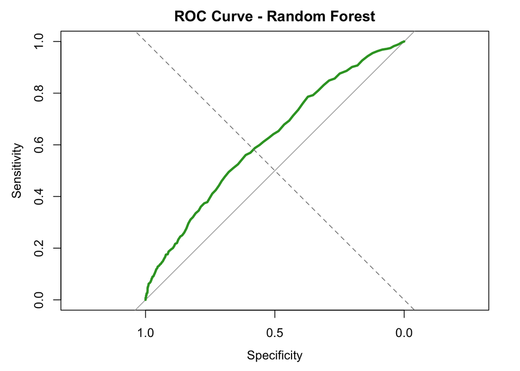

```r
plot(roc_rf, col = "#33A02C", lwd = 3,
     main = "ROC Curve - Random Forest")
abline(a = 0, b = 1, lty = 2, col = "grey50")
```

# Calibration for random forest

```r
rf_calibration_df <- data.frame(
  observed = ifelse(test_rf_clean$readmit30 == "Yes", 1, 0),
  predicted = rf_pred_prob
)

rf_calibration_plot_data <- rf_calibration_df %>%
  mutate(decile = ntile(predicted, 10)) %>%
  group_by(decile) %>%
  summarise(
    mean_predicted = mean(predicted),
    mean_observed = mean(observed),
    .groups = "drop"
  )

rf_calibration_plot_data
```

```
## # A tibble: 10 × 3
##    decile mean_predicted mean_observed
##     <int>          <dbl>         <dbl>
##  1      1         0.0268        0.0433
##  2      2         0.0481        0.0700
##  3      3         0.0643        0.0767
##  4      4         0.0808        0.113
##  5      5         0.0983        0.108
##  6      6         0.117         0.0883
##  7      7         0.137         0.123
##  8      8         0.163         0.133
##  9      9         0.198         0.150
## 10     10         0.289         0.209
```

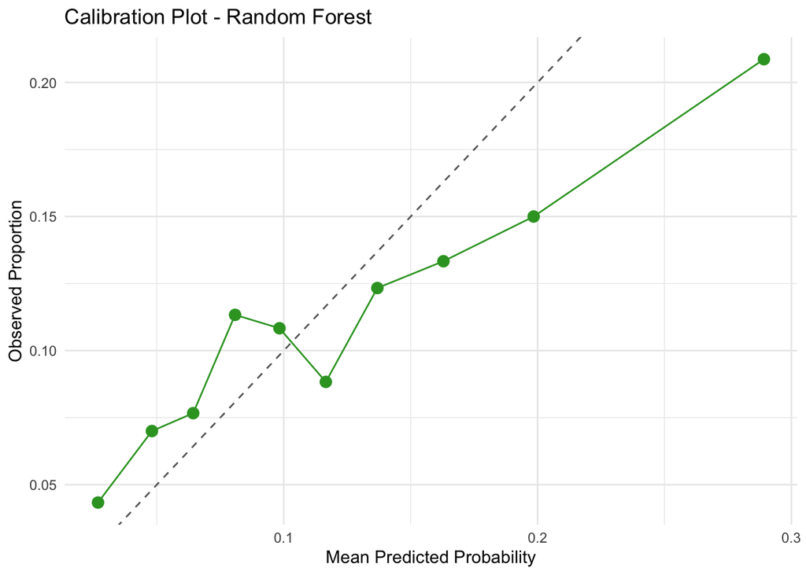

```r
ggplot(rf_calibration_plot_data, aes(x = mean_predicted, y = mean_observed)) +
  geom_point(size = 3, colour = "#33A02C") +
  geom_line(colour = "#33A02C") +
  geom_abline(intercept = 0, slope = 1, linetype = "dashed", colour = "grey40") +
  labs(
    title = "Calibration Plot - Random Forest",
    x = "Mean Predicted Probability",
    y = "Observed Proportion"
  ) +
  theme_minimal()
```

# Brier score for random forest

```r
brier_rf <- mean((rf_calibration_df$observed - rf_calibration_df$predicted)^2)
brier_rf
```

```
## [1] 0.09792897
```

# Variable importance plot

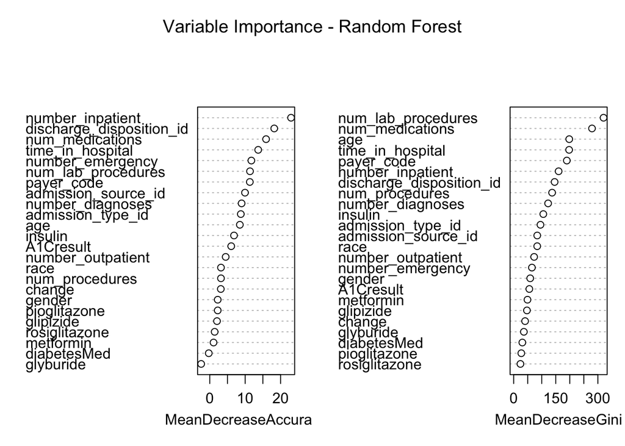

```r
varImpPlot(rf_model, main = "Variable Importance - Random Forest")
```

# Compare model performance

```r
model_comparison <- data.frame(
  Model = c("Logistic Regression", "Random Forest"),
  AUC = c(as.numeric(auc(roc_logit)), as.numeric(auc(roc_rf))),
  Brier_Score = c(brier_logit, brier_rf)
)

model_comparison
```

```
##                 Model       AUC Brier_Score
## 1 Logistic Regression 0.5058291  0.15500171
## 2       Random Forest 0.6191119  0.09792897
```

# Combined ROC plot

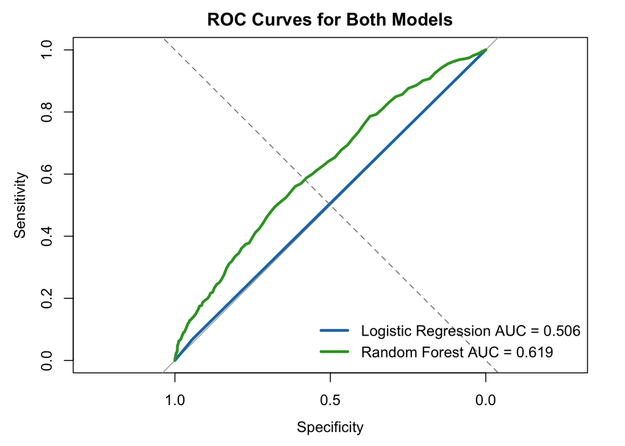

```r
plot(roc_logit, col = "#1F78B4", lwd = 3,
     main = "ROC Curves for Both Models")
plot(roc_rf, col = "#33A02C", lwd = 3, add = TRUE)
abline(a = 0, b = 1, lty = 2, col = "grey50")
legend(
  "bottomright",
  legend = c(
    paste("Logistic Regression AUC =", round(as.numeric(auc(roc_logit)), 3)),
    paste("Random Forest AUC =", round(as.numeric(auc(roc_rf)), 3))
  ),
  col = c("#1F78B4", "#33A02C"),
  lwd = 3,
  bty = "n"
)
```

# Brief Summary

```r
cat("Total observations:", nrow(diabetes), "\n")
```

```
## Total observations: 20001
```

```r
cat("Total variables:", ncol(diabetes), "\n")
```

```
## Total variables: 51
```

```r
cat("Number readmitted within 30 days:",
    sum(diabetes$readmitted == "<30", na.rm = TRUE), "\n")
```

```
## Number readmitted within 30 days: 2232
```

```r
cat("Proportion readmitted within 30 days:",
    round(mean(diabetes$readmitted == "<30", na.rm = TRUE) * 100, 2), "%\n")
```

```
## Proportion readmitted within 30 days: 11.16 %
```

```r
cat("Logistic Regression AUC:", round(as.numeric(auc(roc_logit)), 3), "\n")
```

```
## Logistic Regression AUC: 0.506
```

```r
cat("Random Forest AUC:", round(as.numeric(auc(roc_rf)), 3), "\n")
```

```
## Random Forest AUC: 0.619
```

```r
cat("Logistic Regression Brier Score:", round(brier_logit, 4), "\n")
```

```
## Logistic Regression Brier Score: 0.155
```

```r
cat("Random Forest Brier Score:", round(brier_rf, 4), "\n")
```

```
## Random Forest Brier Score: 0.0979
```

The dataset contains 20,001 observations and 51 variables. Among these, 2,232 patients were readmitted within 30 days, giving a readmission proportion of 11.16%. This indicates that the outcome is relatively uncommon, with most patients not being readmitted within 30 days.

The logistic regression model produced an AUC of 0.506, which is very close to 0.5. This suggests that the model has almost no discriminatory ability and performs only slightly better than random guessing in distinguishing between patients who were and were not readmitted within 30 days. Its Brier score was 0.155, which also indicates relatively weak predictive accuracy.

In contrast, the random forest model achieved an AUC of 0.619, showing better discrimination than logistic regression. Although this is still only a modest level of predictive performance, it suggests that the random forest model is more effective at identifying patients at higher risk of 30-day readmission. The Brier score for random forest was 0.0979, which is notably lower than that of logistic regression, indicating better overall prediction accuracy and calibration.

Overall, the random forest model performed better than logistic regression on this dataset, both in terms of discrimination and prediction error. However, the AUC of 0.619 suggests that prediction of 30-day readmission remains challenging, and further model improvement or inclusion of more informative predictors may be needed.